# Project 2

Lane Quigley

2019-04-06

The Main purpose of this package is to display the DDT dataset in a shiny application that allows the user to visualize and determine the normality of the data. The app is accessed by running the “launchApp()” method. The shiny has mutliple features including being able to select any two numeric variables from the ddt dataset and plot them against each other, add a probability ellipse to the scatterplots and determine what probability (i.e. alpha) to use. The package also has the option to remove outliers in the data using linear models and cook’s distance. The user can choose whether or not to include outliers in the scatterplots. The shiny app includes qq-plots and chi-square plots for each numeric variable in ddt.

## Functions

-launchApp()  
-dataSummary(data)  
-myqq(data)  
-myScatterPairs(data,x,y)  
-myScatterPairsE(data,x,y,percent)  
-OutlierRemoval(data,x,y)  
-OutlierRemovalE(data,x,y)  
-chisqplot(data)  
-mydir()

### Function Details

#### Launch App

**launchApp()**: This method will launch the shinydashboard application and is the main way to interact with the information in this package

#### Data Summary

**dataSummary(data)**: This method is the main constructor method in the package and produce main different analysis statistics of the input data.

#### QQ-Plot

**myqq(data)**: Takes in data finds the numeric variables and produces qqplots for each variable.

#### Scatter Plot

**myScatterPairs(data,x,y)**: Allows the user to input data and choose to variables from the data to produce a scatter plot.

#### Ellipse Scatter Plots

**myScatterPairsE(data,x,y,percent)**: Allows the user to input data and choose to variables from the data to produce a scatter plot. The function also plots a probabilty ellipse around the data with a specified alpha.

#### Outlier Removal

**OutlierRemoval(data,x,y)**: Takes the two variables x and y, creates a linear model of their data and finds outliers based off of the cooks distance. Any values with a cooks distance greater than 4/n where n is the number of observations is removed from the data and plotted.

#### Outlier Removal Ellipse

**OutlierRemovalE(data,x,y,percent)**: Takes the two variables x and y, creates a linear model of their data and finds outliers based off of the cooks distance. Any values with a cooks distance greater than 4/n where n is the number of observations is removed from the data and plotted. In addition the function plots a probability ellipse around the data.

#### Chi-Square plot

**chisqplot(data)**: Takes in a dataset, finds the numeric variables and produces a chi-square plot by findind the statistical distances and calculating the qchisq() quantiles for each observation.

#### Directory

**mydir()**: Outputs the files inside the package directory.

## Examples

dataSummary() example:

```r
ddt=MATH4793QUIG8444::ddt
MATH4793QUIG8444::dataSummary(ddt)
```

```
#> $covariance
#>              MILE     LENGTH      WEIGHT        DDT
#> MILE   10522.7644 -110.43794   1979.5129  381.07923
#> LENGTH  -110.4379   47.36320   1696.3763   85.37993
#> WEIGHT  1979.5129 1696.37631 141786.9743 -441.03479
#> DDT      381.0792   85.37993   -441.0348 9678.34607
#>
#> $meanVector
#> [1]  268.5694   42.8125 1049.7153   24.3550
#>
#> $correlationMatrix
#>               MILE     LENGTH      WEIGHT         DDT
#> MILE    1.00000000 -0.1564346  0.05124780  0.03776155
#> LENGTH -0.15643461  1.0000000  0.65461133  0.12610570
#> WEIGHT  0.05124780  0.6546113  1.00000000 -0.01190568
#> DDT     0.03776155  0.1261057 -0.01190568  1.00000000
#>
#> $numberOfVariables
#> [1] 6
#>
#> $numberNumericVariables
#> [1] 4
#>
#> $numberObservations
#> [1] 144
#>
#> $eigenData
#> eigen() decomposition
#> $values
#> [1] 141838.49690  10648.54189   9524.01203     24.39714
#>
#> $vectors
#>              [,1]         [,2]         [,3]         [,4]
#> [1,]  0.015052006  0.928955987 -0.369649381  0.013173688
#> [2,]  0.011947934 -0.008725272  0.014190113  0.999789857
#> [3,]  0.999809927 -0.012665648  0.008448216 -0.012178614
#> [4,] -0.003285369  0.369870551  0.929024544 -0.009918573
```

myScatterPairsE() example:

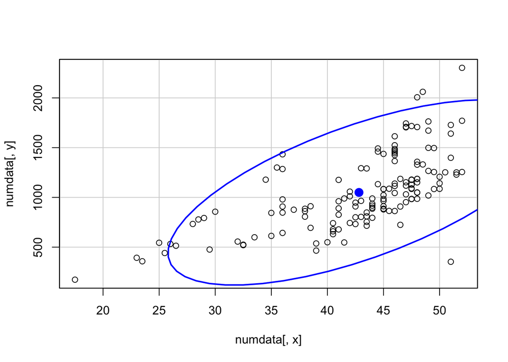

```r
ddt=MATH4793QUIG8444::ddt
MATH4793QUIG8444::myScatterPairsE(ddt,2,3,.95)
```